# Hotspot Spatial Synthesis

Intensity, Relative Intensity, and Multi-service Overlap

Author

Jerónimo Rodríguez Escobar

Published

September 1, 2026

## 1 Overview

1. **Hotspot Intensity (Coverage)**
   - **Question**: What percentage of a region’s own land area is experiencing a crisis for a given service?
   - **Formula**: `(Hotspot Area in Region / Total Area of Region) * 100`
2. **Global Share (Distribution)**
   - **Question**: What percentage of all global hotspots for a service are located within this specific region?
   - **Formula**: `(Hotspot Area in Region / Total Global Hotspot Area) * 100`
3. **Relative Intensity (Enrichment Score)**
   - **Question**: Is a region bearing a disproportionate burden of hotspots compared to its size?
   - **Formula**: `Global Share / Expected Share`, where `Expected Share` is the region’s percentage of the total global land area.
   - **Interpretation**: A score > 1 indicates the region is a “hotspot of hotspots”—it contains more of the crisis than would be expected based on its size alone.
4. **Multi-service Hotspots (“Hotness”)**
   - **Question**: How many overlapping crises are occurring in the same place?
   - **Metrics**: We calculate the average number of overlapping hotspots per gridcell within a region, and the distribution of cells with 1, 2, or 3+ hotspots.
5. **Absolute Population Exposure (Impact Tier)**
   - **Question**: How many people are directly living within these top 5% areas of ES decline?
   - **Metrics**: Total population count within hotspots, segmented by Human Development Index (HDI) vulnerability bins and World Bank Income Group.

## 2 Data Dictionary for Output Tables

This notebook produces three key summary tables in the `processed/tables/` directory. Their columns are defined below.

### 2.1 `hotspot_area_stats.csv`

| Column | Meaning |
| --- | --- |
| `service` | The ecosystem service being analyzed. |
| `group` | The specific value of the grouping variable (e.g., ‘East Asia & Pacific’, ‘Low income’). |
| `n_total` | Total number of valid grid cells within that `group`. |
| `n_hot` | Number of hotspot cells within that `group`. |
| `pct_area` | **Hotspot Intensity (Coverage)**. The percentage of the group’s area that is a hotspot. Formula: `(n_hot / n_total) * 100`. |
| `global_n_hot` | The total number of hotspots for that service across the entire globe. |
| `pct_share` | **Global Share**. The percentage of all global hotspots for a service that are located within this `group`. Formula: `(n_hot / global_n_hot) * 100`. |
| `grouping_var` | The grouping variable used for the aggregation (e.g., ‘region_wb’, ‘income_grp’). |
| `expected_share` | The group’s percentage of the total global land area. This is the share of hotspots the group *would* have if hotspots were distributed evenly. |
| `relative_intensity` | **Enrichment Score**. A measure of disproportionate burden. It is the ratio of the group’s actual share of hotspots to its expected share. A score > 1 indicates the region is a “hotspot of hotspots.” … |

### 2.2 `hotspot_multiservice_stats.csv`

| Column | Meaning |
| --- | --- |
| `group` | The specific value of the grouping variable. |
| `mean_hotspots` | **“Hotness”**. The average number of overlapping service hotspots per grid cell within that group. |
| `pct_multi` | The percentage of grid cells within the group that have more than one hotspot. |
| `n_pixels` | The total number of grid cells in the group. |
| `grouping` | The grouping variable used for the aggregation. |

### 2.3 `hotspot_pop_exposure.csv`

[output not shown]

## 3 Load Data

```
Loading data from: C:/projects/global_NCP/data/processed/plt_long.rds
```

```
Loading canonical grid from: C:/projects/global_NCP/data/processed/10k_change_calc.gpkg
```

```
Found 'grid_fid' column, renaming to 'fid' for standardization.
```

```
Globally excluding '2. High income: nonOECD' from all synthesis calculations.
Original grid_df rows: 1522073
Original plt_long rows: 18264876
```

```
Filtered grid_df rows: 1355270, Filtered plt_long rows: 16263240
```

## 4 Configuration & Exclusions

Hotspot Analysis Configuration Parameters

| Parameter | Value |
| --- | --- |
| Hotspot Cutoff (%) | 5 |
| Threshold Mode | percent |
| Rule Mode | vectors |
| Loss Services | Pollination, Nature_Access |
| Gain Services | N_export, Sed_export, C_Risk |
| Water Combo | N_retention, Sed_retention |
| Access Combo | Nature_Access, Pollination, C_Prot_service |
| Grouping Variables | income_grp, region_wb, WWF_biome, nev_name |
| Service Order | N_export, Sed_export, C_Risk, Pollination, Nature_Access |

### 4.1 Exclusions

The following services are excluded from all calculations: - C_Risk_NoHab - USLE

## 5 Part 1: Intensity, Share, and Relative Intensity

```
Hotspot area statistics saved to: C:/projects/global_NCP/data/processed/tables/hotspot_area_stats.csv
```

## 6 Part 2: Multi-service Overlap (Hotness)

```
--- DEBUG: Checking biomes in df_overlap ---
```

```
Total rows in df_overlap: 1355270
```

```
Unique WWF_biome values found:
```

```
 [1] "Boreal Forests/Taiga"
 [2] "Deserts & Xeric Shrublands"
 [3] "Flooded Grasslands & Savannas"
 [4] "Lakes"
 [5] "Mangroves"
 [6] "Mediterranean Forests, Woodlands & Scrub"
 [7] "Montane Grasslands & Shrublands"
 [8] "Rock & Ice"
 [9] "Temperate Broadleaf & Mixed Forests"
[10] "Temperate Conifer Forests"
[11] "Temperate Grasslands, Savannas & Shrublands"
[12] "Tropical & Subtropical Coniferous Forests"
[13] "Tropical & Subtropical Dry Broadleaf Forests"
[14] "Tropical & Subtropical Grasslands, Savannas & Shrublands"
[15] "Tropical & Subtropical Moist Broadleaf Forests"
[16] "Tundra"
```

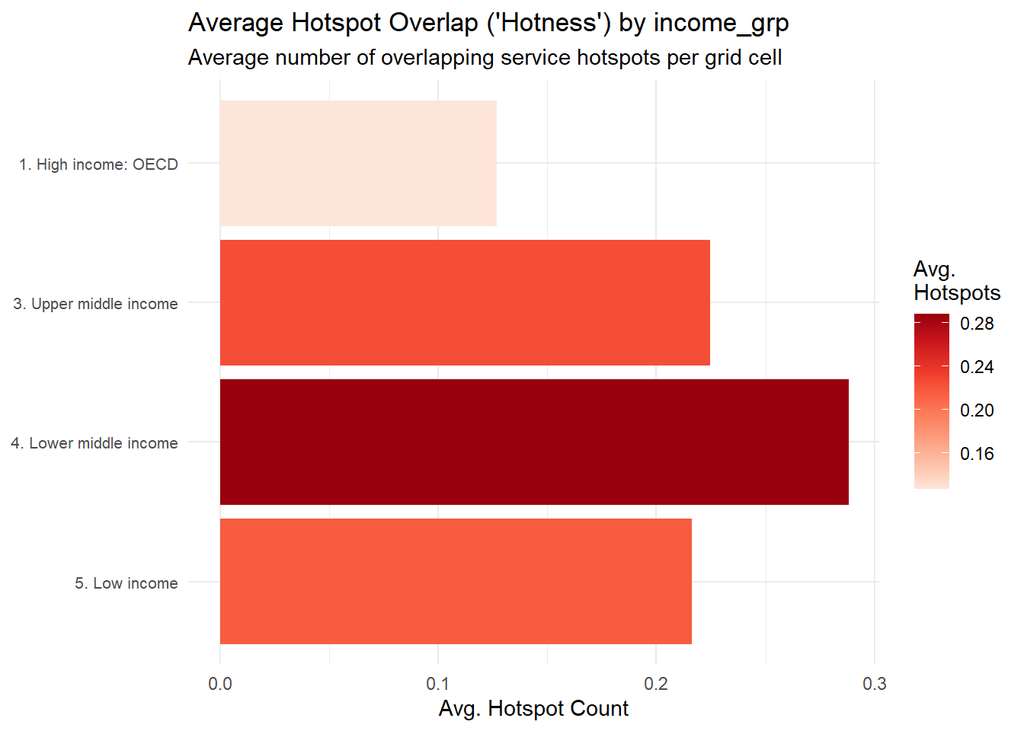

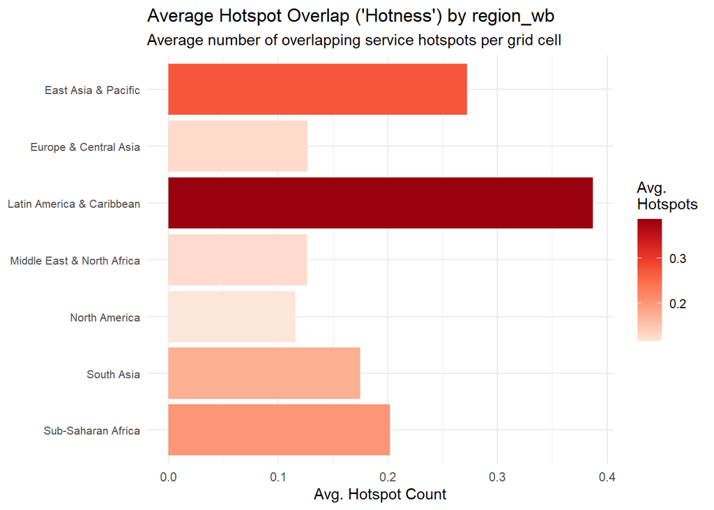

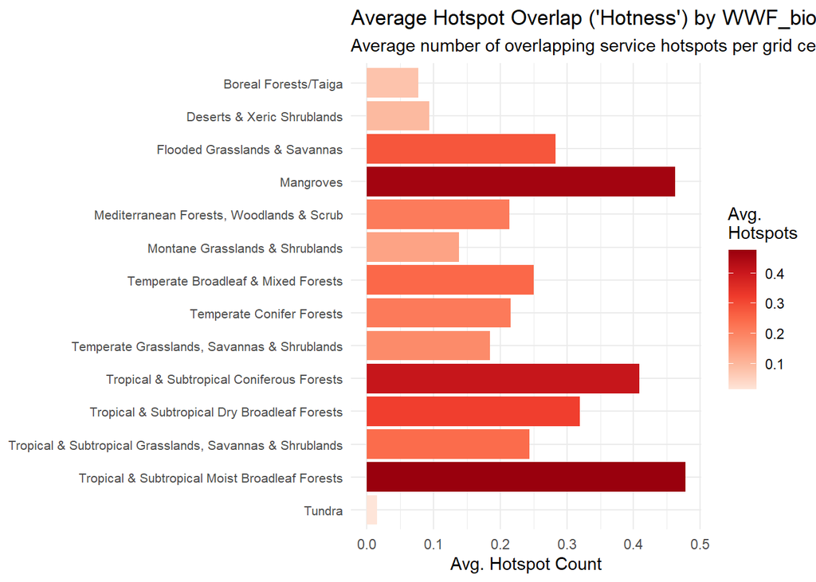

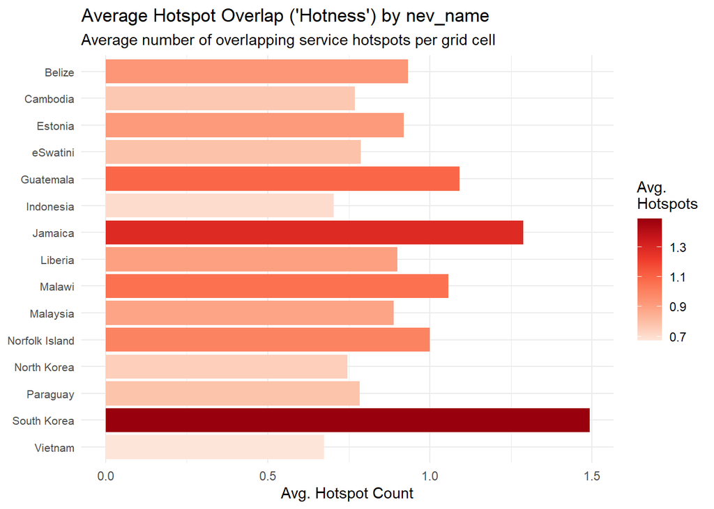

**NoteNote on Aggregation (Sum vs. Mean)**

This analysis uses socioeconomic variables aggregated as both sums (e.g., `GHS_POP_E2020_GLOBE_sum` for total population) and means (e.g., `hdi_raster_predictions_2020_mean` for average HDI).

For reporting absolute exposure, using the `_sum` of population is critical to capture the total number of people affected. For statistical comparisons like the KS test, the choice between sum and mean has no impact on the results because our equal-area grid ensures they are perfectly proportional. For more details, see the “Aggregation Logic: Sum vs. Mean” section in `docs/methodology.md`.

## 8 Regional Subsets Export

Split `hotspot_area_stats.csv` into per-group CSV files under `data/processed/tables/regional_subsets/` so that the regional report template can load them without re-reading the full table.